# Crafting Publication-Ready Graphics in R

## Saving Figures

### Controlling Shape

When you save, you can tell R how wide and tall the picture should be.

```r
ggsave(pic, filename = "pic_width.png", width = 20, height = 10, units = "cm")
```

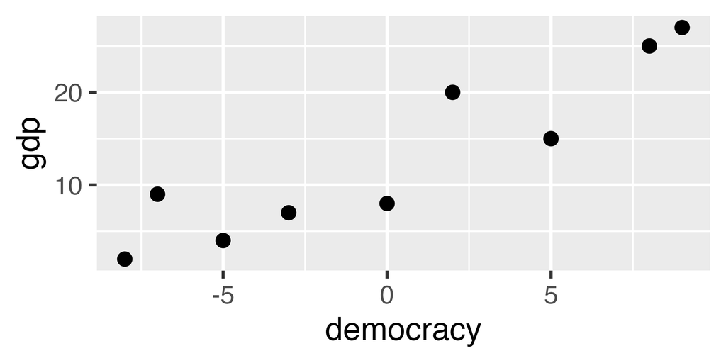

## Saving Figures

### Image Quality

Here’s a new word: **dpi = dots per inch**.

- Higher dpi = sharper image, but larger file.
- Lower dpi = fuzzier image, but smaller file.

```r
ggsave(pic, filename = "pic_hi.png", width = 20, height = 20, units = "cm", dpi = 300)
```

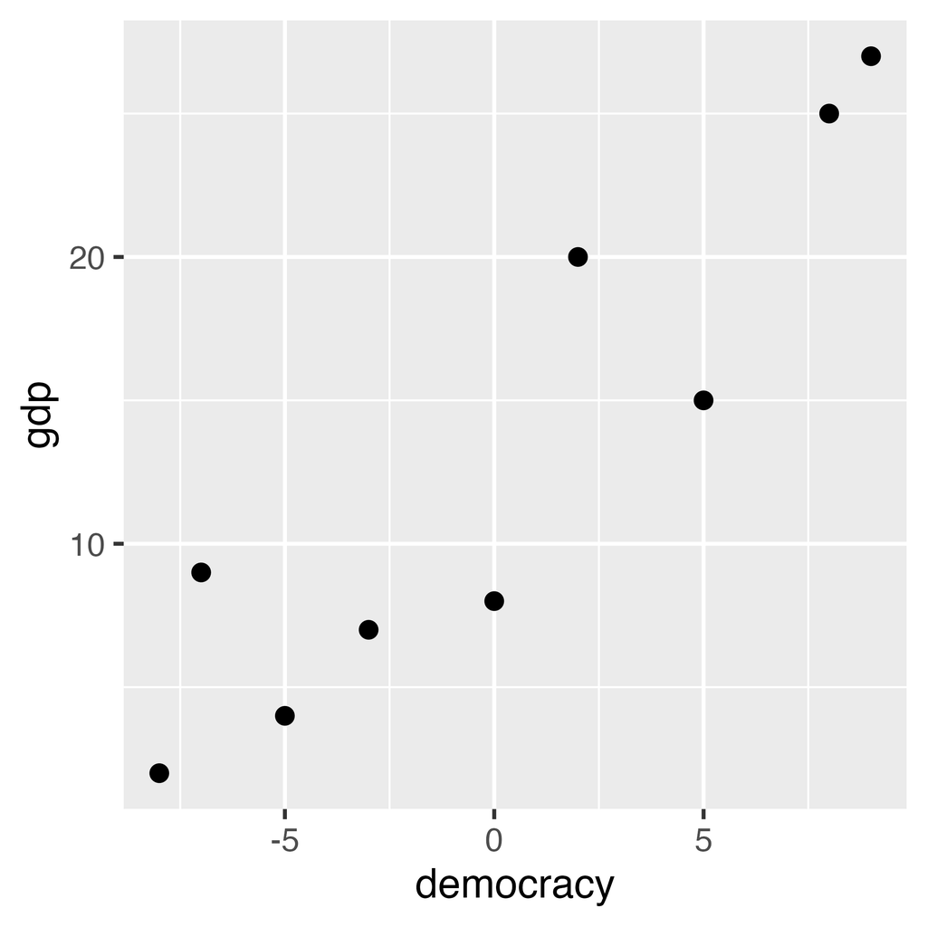

## Saving Figures

### Image Quality

Here’s a new word: **dpi = dots per inch**.

- Higher dpi = sharper image, but larger file.
- Lower dpi = fuzzier image, but smaller file.

```r
ggsave(pic, filename = "pic_lo.png", width = 20, height = 20, units = "cm", dpi = 30)
```

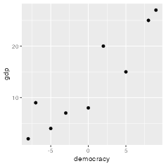

# Conclusion

## Big Takeaways

- **Compose wisely:**
  - Use **facets** when comparisons are *between* groups;
  - Use **color/fill** when comparisons are *within the same axes*.
- **Be honest with coordinates:**
  - Zoom with `coord_cartesian()`;
  - flip long labels with `coord_flip()`.
  - *Avoid misleading truncated axes.*
- **Guide the eye:**
  - Annotations (`geom_text[_repel]`, `geom_label[_repel]`, arrows) for **readable stories**.
- **Context matters:** `labs()` for titles, subtitles, axes, captions, and clear legends.
- **Polish with themes:** Built-ins or `ggthemes` to professionalize—**data first, décor second**.
- **Combine & share:**
  - `ggarrange()` to curate narratives;
  - `gganimate`/`ggiraph` to add motion/interaction;
  - `ggsave` to export with the right size & DPI.